# Homework 2

## 1. Probability Warmup (1pt each, 6pts total)

1. Consider $X\sim \text{Normal}(3, 4^2)$. Find $P(4 < X < 7)$

```r
pnorm(7,mean = 3, sd=4)-pnorm(4,mean = 3,sd=4)
```

```
## [1] 0.2426384
```

2. For $X$ above, find the 75th percentile, i.e. find $q$ such that $P(X < q)=.75$

```r
qnorm(0.75,mean = 3, sd= 4)
```

```
## [1] 5.697959
```

3. Consider $Y\sim Geometric(.25)$. Find $P(Y \leq 5)$ note:dgeom is the number of failier at the first success pgeom is the number of failier before the first success

```r
pgeom(5,0.25)
```

```
## [1] 0.8220215
```

4. Consider $W \sim Poisson(8)$. Find $P(W \geq 13)$

```r
1-ppois(12, lambda =8 )
```

```
## [1] 0.0637972
```

5. What is the 95th percentile for $W$? Is the probability less than this value exactly 95%? (If not, then why?)

```r
qpois(0.95,lambda = 8)
```

```
## [1] 13
```

because the Poisson distribution is discrete, its cumulative distribution function increases in step jumps, so exact probabilities like $0.95$ are rarely hit precisely

6. Assuming they are independent, what is the expected value and variance of $X+Y+W$?

```r
exp_X <- 3; Var_X <- 4^2
exp_Y <- (1 - 0.25) / 0.25; Var_Y <- (1 - 0.25) / (0.25^2)
exp_W <- 8; Var_W <- 8

total_E <- exp_X + exp_Y + exp_W
total_Var <- Var_X + Var_Y + Var_W
```

## 2. Choosing the best model (1pt each, 7 pts total)

For each of the following scenarios, decide what random variable may be appropriate to use as a model, and explain your reasoning as well as any assumptions you make.

1. The number of patients in an experimental drug trial that respond to treatment. Binomial random variable
2. The number of red cars you observe driving through an intersection between 10am and 11am. Poisson random variable
3. What the second hand reads on the clock when you wake up (without an alarm clock) from a long nap (approximately). uniform distribution
4. How many people you need to swipe right on Tinder before you get a match. geometric random variable
5. The length of time between mosquito bites a camper experiences while on a hike. Exponential random variable
6. Whether the Eagles win the Superbowl this year. bernouli random vatriable
7. The GPA of a randomly selected UW-Madison graduate.

continuous random variable

## 3. Mousetrap: A Rube Goldberg Machine (1pt each, 5pts total)

Consider the board game [Mousetrap](https://youtu.be/fOyq6Nc8660?si=WFJ-ldFsqsxg0Khx). When you trigger the trap, the ball needs to

1. roll down a **ramp**,
2. be carried up by a **hammer**,
3. roll down another **ramp**,
4. go down a bathtub **drain**,
5. land on a **lever** which
6. sends a diver into a **basin** which then
7. causes the **trap** to descend.

Suppose you can model the success of each component as independent Bernoulli random variables $X_1$ through $X_7$, where the probability of $X_i$ succeeding is $.85$ for each component (this is an arbitrary probability for this HW problem).

1. What is the probability that the trap works correctly from beginning to end?

```r
prop<-0.85**7
prop
```

```
## [1] 0.3205771
```

2. If you attempt the trap 20 times during a game, how many times do you expect it to work correctly from beginning to end?

```r
prop*20
```

```
## [1] 6.411542
```

3. Suppose you let the marble go: Let $Y$ be the number of components of the trap that work in a row. If one component fails, then you stop counting. Calculate the probability mass function of $Y$. *Hints: $Y$ can have values $0, 1, 2, 3, 4, 5, 6$ or $7$. This is like a Geometric r.v. except it does not have infinite support. How can you use this fact to determine the pmf? Be careful: what is a ‘success’ in this context?*

```r
p_f <- 0.15

pmf <- c(dgeom(0:6, prob = p_f), 1 - pgeom(6, prob = p_f))

names(pmf) <- 0:7
print(pmf)
```

```
##          0          1          2          3          4          5          6
## 0.15000000 0.12750000 0.10837500 0.09211875 0.07830094 0.06655580 0.05657243
##          7
## 0.32057709
```

4. Calculate the expected value of $Y$ and its variance.

```r
exp_value<-(1-pmf)/pmf
exp_value
```

```
##         0         1         2         3         4         5         6         7
##  5.666667  6.843137  8.227220  9.855553 11.771239 14.024987 16.676456  2.119375
```

5. What is $P(Y = 6 | Y \geq 3)$?

```r
Y_3<-pgeom(2,prob = 0.15)
Y_3
```

```
## [1] 0.385875
```

```r
Y_6<-dgeom(6,prob =0.15)
Y_6
```

```
## [1] 0.05657243
```

```r
Y_6/(1-Y_3)
```

```
## [1] 0.09211875
```

## 4. Correlated Normal Random Variables (2pts each, 10pts total)

Let $X$ and $Y$ be normally distributed random variables with $\mu_X=50$ and $\mu_Y=30$. Their covariance matrix given by
$$\Sigma = \left[\begin{matrix}100 &
75\\75 & 225\end{matrix}\right]$$
In other words, $\sigma^2_X=10^2$, $\sigma^2_Y=15^2$ and $\rho_{XY}=.5$.

1. Using the rules of combining random variables, find the distribution of $X+Y$. (*hint: the sum of two normally distributed random variables will also follow a normal distribution*)

```r
exp<- 50+30
variance<-100+225+75+75
exp
```

```
## [1] 80
```

```r
variance
```

```
## [1] 475
```

```r
sd_XY=sqrt(variance)
sd_XY
```

```
## [1] 21.79449
```

2. Calculate $Pr[60 < X+Y < 90]$

```r
Pr<-pnorm(90,mean = 80, sd=sd_XY)-pnorm(60, mean=80,sd=sd_XY)
Pr
```

```
## [1] 0.4974247
```

To simulate values from this distribution we can use the `mvrnorm` function in the MASS package. The following code will generate a dataframe with 10000 samples from this distribution.

```r
library(MASS)
mu <- c(50,30)
Sigma <- matrix(c(100,75,75,225), byrow=T, nrow=2)
XYdata <- mvrnorm(10000, mu, Sigma)
colnames(XYdata) <- c("X","Y")
XYdata <- as.data.frame(XYdata)
# un-comment the next line to plot the data
# ggplot(XYdata) + geom_point(aes(x=X, y=Y), pch=1)
```

3. Create a new column `W` that is `X+Y`. Using the values in this column, verify your answer for part a. using a histogram and calculating the mean and variance of $W$.

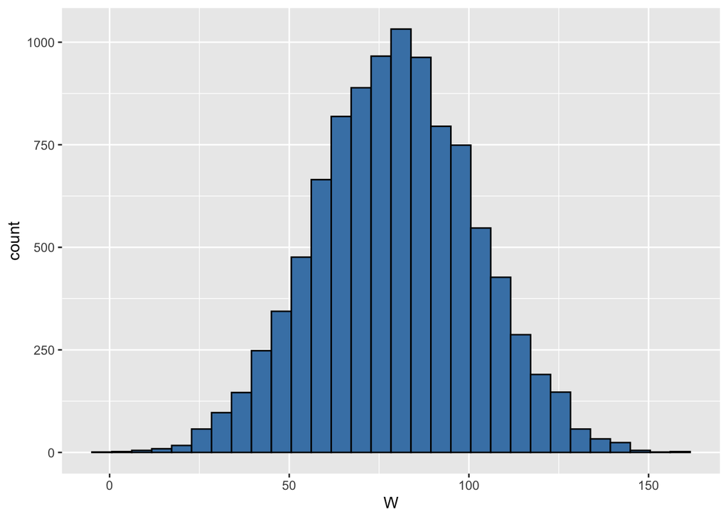

```r
XYdata$W<- XYdata$X + XYdata$Y
ggplot(XYdata, aes(x = W)) + geom_histogram(color = "black", fill = "steelblue")
```

```r
mean(XYdata$W)
```

```
## [1] 79.72454
```

```r
var(XYdata$W)
```

```
## [1] 483.4685
```

4. Using the values in `W`, verify your answer for part b.

```r
d<-mean(XYdata$W>60 & XYdata$W<90)
d
```

```
## [1] 0.4965
```

5. Using your simulated data, approximate an answer to $Pr(Y > 50 | X > 65)$.

```r
mean(XYdata$Y[XYdata$X > 65] > 50)
```

```
## [1] 0.3431085
```

## 5. The Geometric, The Poisson and the Exponential (2pts each, 14pts total)

In this problem we’ll explore the relationship between three random variable distributions.

Suppose we’re modeling an experiment where photons hit a glass plate. The average rate of collision is 90/second.

1. What is the probability that 100 or fewer photons hit the plate in one second?

```r
ppois(100,lambda=90)
```

```
## [1] 0.8650998
```

2. After a photon hits, what is the probability that it takes .03 or fewer seconds for the next photon to hit?

```r
pexp(.03,rate = 90)
```

```
## [1] 0.9327945
```

3. What is the probability that it takes 1 millisecond (.001 seconds) or fewer for the first collision?

```r
p<-pexp(.001,rate = 90)
p
```

```
## [1] 0.08606881
```

The following code will simulate the times between collisions in seconds.

```r
collision.s <- rexp(10000, 90)
```

Suppose we are counting collisions per second. The following code will count how many collisions occur during each second of the experiment.

```r
collision.count <-
  as.vector(tabulate(floor(cumsum(collision.s))))
collision.count
```

```
##   [1]  88  98  79  88  93  78  86  96 100  84  95  86  98  88  92  92  88  99
##  [19]  89 111  91  94  98 113  89  90 101  93  85  85  93 101 110 105  74  88
##  [37] 102  74  80  80  91  90  84  79  86  89  77  85  90  92  87  90  89 105
##  [55] 104  98  81  88  98 111  92  97  98  88  85 101  74  94 100  92  85  91
##  [73]  91  84  85  99  75  93  76  88  84  82  70  94  79 104  89  78  79  93
##  [91] 102  89  96  87 100  85  82  91  87 111  80 100  96  81  85  87  87  91
## [109]  88  48
```

4. Plot a histogram of the `collision.count`. What is the mean number of collisions per second? In theory what should the distribution of `collision.count` be *(hint: think about the Poisson distribution)*?

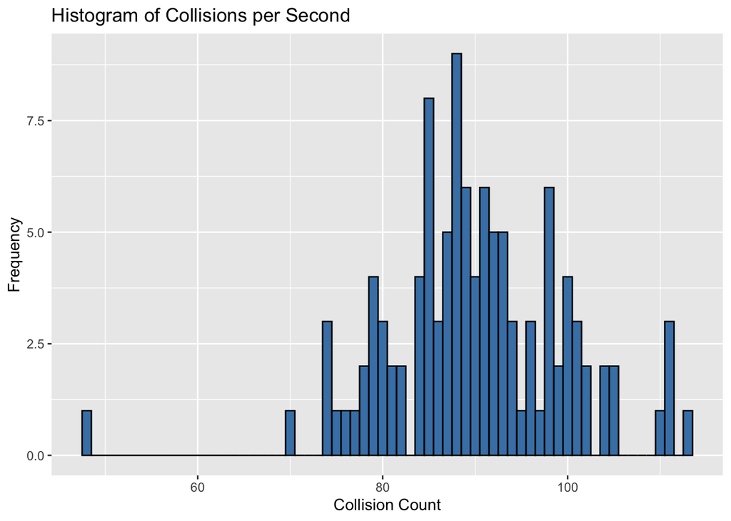

```r
histogram <- data.frame(collision.count) %>%
  ggplot(aes(x = collision.count)) +
  geom_histogram(binwidth = 1, color = "black", fill = "steelblue") +
  labs(
    title = "Histogram of Collisions per Second",
    x = "Collision Count",
    y = "Frequency"
  )

histogram
```

```r
mean(collision.count)
```

```
## [1] 90.00909
```

In theory, collision.count follows a $\text{Poisson}(\lambda = 90)$ distribution.

Now we’ll see how the exponential is related to the geometric distribution. Suppose we were to round down to the nearest millisecond - to convert seconds to milliseconds, multiply by 1000, and round **down** (*floor*) to the nearest integer. In this sense, we could consider the data recorded as “counting how many milliseconds before the next collision”.

5. Convert to milliseconds and save this vector as `collision.ms`. Plot a histogram of the milliseconds, and calculate the mean and variance. If you were to model the collision time (ms) as a geometric random variable, what parameter $p$ would you use? (*hint: the expected value of a geometric rv is $\frac{1}{p}-1$.*)

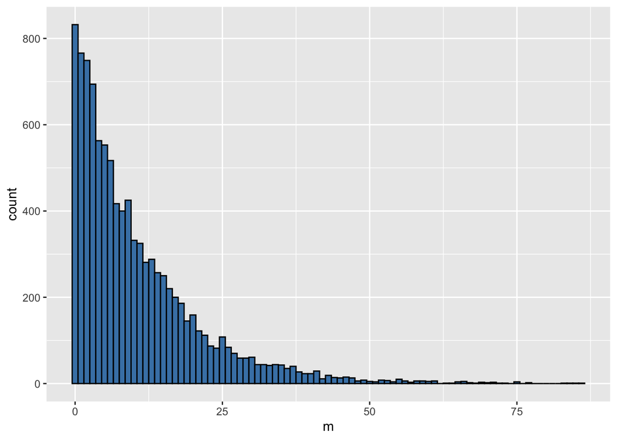

```r
m <- floor(collision.s * 1000)

data.frame(m) %>% ggplot(aes(x = m)) +
  geom_histogram(binwidth = 1, color = "black", fill = "steelblue")
```

```r
mean(m)
```

```
## [1] 10.5623
```

```r
var(m)
```

```
## [1] 118.9146
```

```r
# Estimate p: E[m] = (1-p)/p -> p = 1 / (mean(m) + 1)
p_est <- 1 / (mean(m) + 1)
p_est
```

```
## [1] 0.08648798
```

6. If we record our data in milliseconds rather than seconds, what would the average number of collisions per millisecond be?

```r
collisions_per_ms <- 90 / 1000
collisions_per_ms
```

```
## [1] 0.09
```

7. If you have $Y \sim Exp(\lambda)$, it turns out that the floor function $\lfloor{Y}\rfloor \sim Geom(1-e^{-\lambda})$. Check to see if $1-e^{-\lambda}$ is close to the $p$ you found earlier.

```r
lambda_ms <- 90 / 1000  # 0.09

p_theoretical <- 1 - exp(-lambda_ms)
p_theoretical
```

```
## [1] 0.08606881
```

```r
p_estimated <- 1 / (mean(m) + 1)
p_estimated
```

```
## [1] 0.08648798
```

```r
abs(p_theoretical - p_estimated)
```

```
## [1] 0.0004191678
```

## 6. Random Variables in a Coffee Shop (1pt each, 8pts total)

A small coffee shop records the number of customers arriving each morning between 8–9 a.m. They have noticed that:

- On average, 12 customers arrive in that hour. The arrivals can be modeled as a Poisson random variable.
- Each customer spends, on average, $5.50 with a standard deviation of $1.50. The spending per customer is independent and approximately follows a Normal distribution.

Let $X$ be the number of customers who arrive between 8–9 a.m.

1. Write down the distribution of $X$.

```r
lambda<-12
lambda
```

```
## [1] 12
```

2. What is the probability that exactly 10 customers arrive in an hour?

```r
dpois(10,lambda = 12)
```

```
## [1] 0.1048373
```

3. What is the probability that at least 15 customers arrive in an hour?

```r
1-ppois(14,lambda = 12)
```

```
## [1] 0.2279755
```

Let $Y$ be the spending of a single customer.

4. State the distribution of $Y$.

Y:Y<- N(5.50,1.50^2)

5. What is the probability a single customer spends more than $6?

```r
1-pnorm(6,mean = 5.50, sd=1.50)
```

```
## [1] 0.3694413
```

Now let $W$ be the total revenue between 8–9 a.m.

6. What is the expected value of $W$?

```r
exp_val<-12*5.50
exp_val
```

```
## [1] 66
```

7. What is the variance of $W$? (*hint: $W$ is a random sum: $W=\sum_{i=1}^X Y_i$. The variance of a random sum is $Var(W)=EX\cdot VarY + VarX \cdot E^2Y$*)

```r
EX <- 12
VarX <- 12
EY <- 5.50
VarY <- 1.50^2

VarW <- (EX * VarY) + (VarX * (EY^2))
VarW
```

```
## [1] 390
```

8. Explain why the exact distribution of $W$ is complicated. Suggest a method that could be used to approximate it.

Usually, probability problems only have one moving part. Here, two independent things fluctuate at the exact same time:

You don’t know how many people walk through the door (it could be 5, 12, or 20).

You don’t know how much money each individual spends (one person buys a 3 dollar drip coffee; another spends $15 on lattes and pastries)

Normal Approximation (Central Limit Theorem)Since the expected number of arrivals ($\lambda = 12$) is moderately large, $W$ can be approximated using a single Normal distribution parameterized by the mean $E[W]$ and variance $\text{Var}(W)$ found in parts f and g:
$$W \approx \text{Normal}(\mu = 66, \,
\sigma^2 = 390)$$